# Stochastic SIR model in POMP

## R Markdown

I used POMP to create a deteministic and a stochastic version of the basic SIR model. I am using the discrete difference equations version for both. POMP stores all data in its own pomp class that can be used for complicated methods in the package, so I hope it will be easier to implement algorithms later within the package.

We start by specifying the deterministic model skeleton, I use the following equations:  
(“D” signifies the update value for the map in the equations)

```r
# deterministic skeleton
skel <- Csnippet("
  DS = S - Beta*S*I/N;
  DI = I + Beta*S*I/N-gamma*I;
  DR = R + gamma*I;
")
```

Then I specify the stochastic stepping process:  
I used 1-exp(r) for the per capita stepping probabilities for rate r in the difference eqs and a binomial distribution for the numbers of individuals moving between compartments.

```r
# stochastic stepping process
stochStep <- Csnippet("
  p_SI = 1 - exp(-Beta*I/N);
  p_IR = 1 - exp(-gamma);

  n_SI = rbinom(S,p_SI);
  n_IR = rbinom(I,p_IR);

  S = S - n_SI;
  I = I + n_SI - n_IR;
  R = R + n_IR;

")
```

I set some arbitrary initial states and parameters (one infected out of 763, I think something like measles has parameters like that? )

```r
# initial values of states
init1 <- Csnippet("
  S = N-1;
  I = 1;
  R = 0;
  ")

params1 <- c(Beta=1, gamma = 1/13, N= 763)
```

Then we can create a POMP object:  
We follow the process for 50 days, POMP will use our stochastic process described above.

```r
closed_sir <- pomp(data=data.frame(time=1:50,data=NA),
                   times="time",
                   t0=0,
                   rprocess=discrete_time(step.fun=stochStep,delta.t=1),
                   skeleton = map(skel),
                   rinit=init1,
                   statenames=c("S","I","R", "p_SI", "p_IR", "n_SI", "n_IR"),
                   paramnames=c("Beta","gamma","N"))
```

```r
sim <- simulate(closed_sir,params=params1,format = "data.frame", nsim = 100)
head(sim, 3)
```

```
##   time .id   S I R        p_SI       p_IR n_SI n_IR data
## 1    1   1 762 1 0 0.001309758 0.07403892    0    0   NA
## 2    1   2 760 3 0 0.001309758 0.07403892    2    0   NA
## 3    1   3 761 2 0 0.001309758 0.07403892    1    0   NA
```

```r
tail(sim, 3)
```

```
##      time .id   S  I   R       p_SI       p_IR n_SI n_IR data
## 4998   50  98   0 26 737 0.04107241 0.07403892    0    6   NA
## 4999   50  99   0 58 705 0.07925192 0.07403892    0    5   NA
## 5000   50 100 762  0   1 0.00000000 0.07403892    0    0   NA
```

```r
traj <- trajectory(closed_sir,params=params1,format="data.frame")
head(traj, 3)
```

```
##          S        I          R p_SI p_IR n_SI n_IR time .id
## 1 761.0013 1.921766 0.07692308   NA   NA   NA   NA    1   1
## 2 759.0846 3.690670 0.22475125   NA   NA   NA   NA    2   1
## 3 755.4128 7.078504 0.50864897   NA   NA   NA   NA    3   1
```

```r
tail(traj,3)
```

```
##               S        I        R p_SI p_IR n_SI n_IR time .id
## 48 1.750527e-05 36.11996 726.8800   NA   NA   NA   NA   48   1
## 49 1.667658e-05 33.34151 729.6585   NA   NA   NA   NA   49   1
## 50 1.594785e-05 30.77678 732.2232   NA   NA   NA   NA   50   1
```

We then plot to see how the stochastic results differ from the deterministic trajectory:

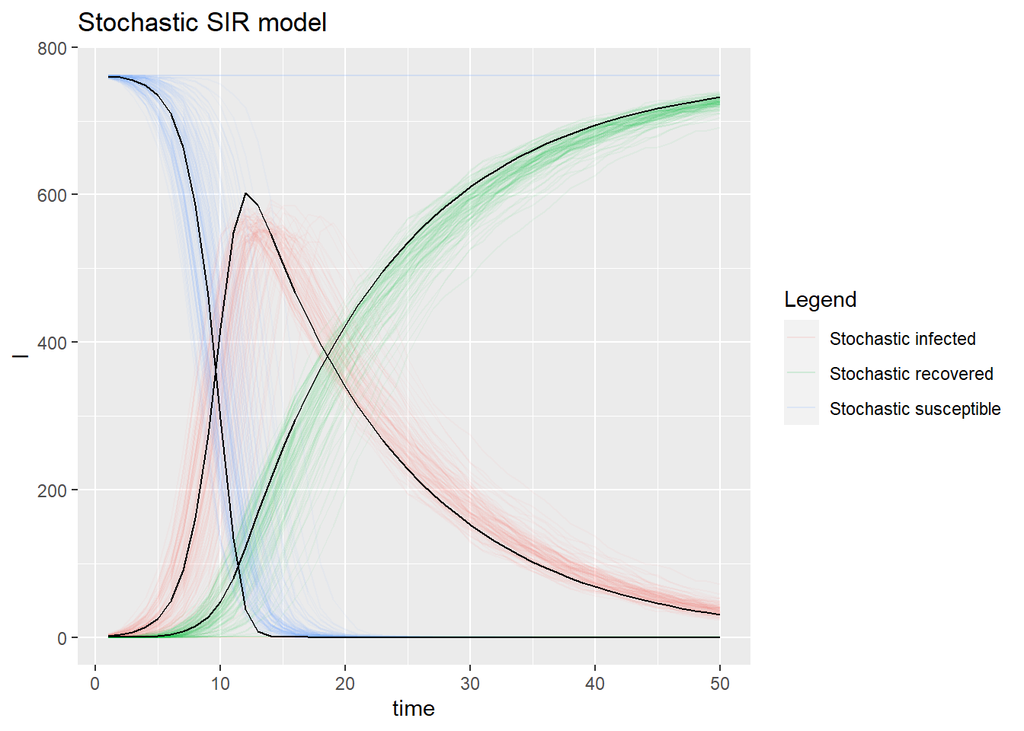